# **Zillow Home‑Price Prediction Using Public Housing & Demographic Data**

*Leane Steyn, Lillian Paul, Alex Lang*

# **Business Problem and Goal Analysis**

Zillow is one of the largest real‑estate marketplaces in the U.S., offering home‑value estimates (Zestimates) and market insights. Accurately predicting home prices is challenging due to regional economic differences, demographic shifts, and market volatility.  
This project uses Zillow Home Value Index (ZHVI) data and U.S. Census ACS demographic indicators to identify key drivers of home‑price variation and build predictive models for estimating future home values.

**Goal:** Build 2–3 machine‑learning models to predict home values and interpret which features matter most.

# **Business challenge**

Zillow’s pricing accuracy directly affects user trust, platform engagement, and real‑estate decision‑making.  
Home prices fluctuate due to income levels, population growth, education, housing supply, and regional economic conditions.  
Improving predictive accuracy helps Zillow:

- Provide more reliable Zestimates
- Support buyers and sellers
- Strengthen investor insights

# **Industry Context**

The U.S. housing market is influenced by macroeconomic factors such as interest rates, migration patterns, and local affordability. Public datasets like ACS provide essential demographic context.

# **DataSet:**

- **ZHVI (Zillow Home Value Index):** Monthly home‑value estimates by region.
- **ACS Demographic Data:** Income, education, population, housing characteristics.

Loading Libraries

```python
import pandas as pd
import numpy as np
import matplotlib.pyplot as plt
import seaborn as sns

from sklearn.model_selection import train_test_split
from sklearn.linear_model import LinearRegression, Lasso
from sklearn.ensemble import RandomForestRegressor
from sklearn.metrics import mean_squared_error, mean_absolute_error, r2_score

sns.set(style="whitegrid")
print("Libraries loaded.")
```

```
Libraries loaded.
```

Load Datasets

```python
zhvi_path = "/content/ZHVI.csv"
acs_path = "/content/acs2015_census_tract_data.csv.zip"

zhvi = pd.read_csv(zhvi_path)
acs = pd.read_csv(acs_path)

print("ZHVI shape:", zhvi.shape)
print("ACS shape:", acs.shape)
```

```
ZHVI shape: (314, 52)
ACS shape: (74001, 37)
```

Data Understanding:

Inspect zhvi

```python
zhvi.head()
```

|  | Unnamed: 0 | Florida | California | Texas | New York | Virginia | Washington | Michigan | Colorado | New Jersey | ... | West Virginia | Kansas | Kentucky | South Dakota | Delaware | Wisconsin | North Dakota | Nebraska | Oklahoma | Alaska |
| --- | --- | --- | --- | --- | --- | --- | --- | --- | --- | --- | --- | --- | --- | --- | --- | --- | --- | --- | --- | --- | --- |
| 0 | 2000-01-01 | 107549.759105 | 187986.834929 | 112895.976760 | 150045.977338 | 123684.552511 | 173367.823567 | 113899.824293 | 176682.186996 | 167343.438986 | ... | 72317.787856 | 87678.600553 | 89439.194558 | 106063.481039 | 146615.955734 | 117744.489235 | NaN | 114189.523309 | 82670.964090 | 134147.013970 |
| 1 | 2000-02-01 | 107782.721894 | 188618.714792 | 112957.327350 | 150580.288409 | 124004.602634 | 173758.878834 | 113962.557597 | 177309.536197 | 167794.538176 | ... | 72314.692267 | 87695.812028 | 89485.371575 | 105838.131182 | 146844.056513 | 117710.316247 | NaN | 114372.059982 | 82705.066072 | 134299.376638 |
| 2 | 2000-03-01 | 108065.119232 | 189471.907336 | 112987.083347 | 151094.648981 | 124343.930892 | 174157.790022 | 114192.228542 | 178002.821966 | 168224.966274 | ... | 72338.067604 | 87797.212329 | 89569.388767 | 105522.770731 | 147128.062514 | 117842.040500 | NaN | 114541.237906 | 82864.026338 | 134451.659620 |
| 3 | 2000-04-01 | 108639.160386 | 191323.933952 | 113134.765000 | 152200.898743 | 124985.148445 | 174962.894781 | 114649.732163 | 179552.984021 | 169178.593471 | ... | 72397.231969 | 87948.798721 | 89778.179177 | 105097.698666 | 147777.577805 | 118031.209121 | NaN | 114803.853379 | 83153.484649 | 134630.251965 |
| 4 | 2000-05-01 | 109258.201912 | 193476.635902 | 113230.405955 | 153345.471798 | 125604.173757 | 175841.616004 | 115324.416480 | 181283.233628 | 170150.741418 | ... | 72512.658668 | 88177.301635 | 90055.667426 | 104920.856265 | 148518.378903 | 118408.615469 | NaN | 114937.028176 | 83542.272174 | 134899.108748 |

5 rows × 52 columns

```python
zhvi.info()
```

```
<class 'pandas.core.frame.DataFrame'>
RangeIndex: 314 entries, 0 to 313
Data columns (total 52 columns):
 #   Column                    Non-Null Count  Dtype
---  ------                    --------------  -----
 0   Unnamed: 0                314 non-null    object
 1   Florida                   314 non-null    float64
 2   California                314 non-null    float64
 3   Texas                     314 non-null    float64
 4   New York                  314 non-null    float64
 5   Virginia                  314 non-null    float64
 6   Washington                314 non-null    float64
 7   Michigan                  314 non-null    float64
 8   Colorado                  314 non-null    float64
 9   New Jersey                314 non-null    float64
```

[output cut: 44 more lines]

```python
zhvi.describe()
```

|  | Florida | California | Texas | New York | Virginia | Washington | Michigan | Colorado | New Jersey | Massachusetts | ... | West Virginia | Kansas | Kentucky | South Dakota | Delaware | Wisconsin | North Dakota | Nebraska | Oklahoma | Alaska |
| --- | --- | --- | --- | --- | --- | --- | --- | --- | --- | --- | --- | --- | --- | --- | --- | --- | --- | --- | --- | --- | --- |
| count | 314.000000 | 314.000000 | 314.000000 | 314.000000 | 314.000000 | 314.000000 | 314.000000 | 314.000000 | 314.000000 | 314.000000 | ... | 313.000000 | 314.000000 | 314.000000 | 313.000000 | 314.000000 | 314.000000 | 206.000000 | 314.000000 | 314.000000 | 313.000000 |
| mean | 217831.358873 | 448160.461981 | 180059.818355 | 294846.955048 | 251651.791299 | 331166.863303 | 148851.317929 | 315761.057864 | 331865.131765 | 378254.924071 | ... | 110427.345278 | 137284.264348 | 134366.307637 | 176589.167291 | 256543.989614 | 185045.704120 | 214590.560927 | 156684.529824 | 129036.905433 | 259689.242801 |
| std | 87179.766710 | 170465.225159 | 64398.529399 | 87655.237641 | 71609.093443 | 132051.658175 | 44600.703219 | 122820.841420 | 91886.846979 | 114067.677917 | ... | 25463.649275 | 41211.650590 | 39562.408264 | 61518.473281 | 64715.888680 | 53049.665100 | 34937.804730 | 48087.851757 | 37518.345064 | 63128.308170 |
| min | 107549.759105 | 187986.834929 | 112895.976760 | 150045.977338 | 123684.552511 | 173367.823567 | 91470.235236 | 176682.186996 | 167343.438986 | 193455.899605 | ... | 72314.692267 | 87678.600553 | 89439.194558 | 104559.920310 | 146615.955734 | 117710.316247 | 159412.237781 | 107237.690658 | 82670.964090 | 134147.013970 |
| 25% | 147591.775179 | 304344.101356 | 135307.617906 | 249710.185392 | 216614.375669 | 230743.443771 | 119100.875200 | 224046.284432 | 278855.889802 | 303021.095140 | ... | 98422.751324 | 112945.450926 | 110662.148913 | 136378.837300 | 216535.340684 | 150216.054081 | 186625.790490 | 125389.034643 | 107169.882055 | 226518.509457 |
| 50% | 196888.271842 | 420306.545701 | 145139.878533 | 272185.407423 | 242265.329738 | 286271.199590 | 137582.560595 | 239739.259240 | 312653.539209 | 345619.593176 | ... | 102758.796303 | 118883.846490 | 115572.040638 | 153932.191352 | 247391.783677 | 167545.078257 | 219952.825281 | 131845.244900 | 112727.222240 | 253774.337023 |
| 75% | 253951.509118 | 537807.639910 | 213655.542908 | 338510.897960 | 273443.529118 | 394510.848481 | 165887.044257 | 393803.460399 | 361430.251889 | 420806.169919 | ... | 116906.854274 | 150319.353740 | 148030.957013 | 203620.304103 | 274255.622755 | 202013.413595 | 240329.588993 | 176989.319025 | 139395.776703 | 304076.361158 |
| max | 399771.118655 | 779805.833110 | 312894.365605 | 502162.146331 | 405473.906761 | 599409.492772 | 254229.984082 | 568201.094125 | 558900.050824 | 642386.737927 | ... | 169779.858230 | 239110.907469 | 230371.428512 | 312005.430396 | 396206.927725 | 322640.532825 | 280509.534392 | 271337.597588 | 216242.122759 | 380987.433189 |

8 rows × 51 columns

Inspect ACS

```python
acs.head()
```

|  | CensusTract | State | County | TotalPop | Men | Women | Hispanic | White | Black | Native | ... | Walk | OtherTransp | WorkAtHome | MeanCommute | Employed | PrivateWork | PublicWork | SelfEmployed | FamilyWork | Unemployment |
| --- | --- | --- | --- | --- | --- | --- | --- | --- | --- | --- | --- | --- | --- | --- | --- | --- | --- | --- | --- | --- | --- |
| 0 | 1001020100 | Alabama | Autauga | 1948 | 940 | 1008 | 0.9 | 87.4 | 7.7 | 0.3 | ... | 0.5 | 2.3 | 2.1 | 25.0 | 943 | 77.1 | 18.3 | 4.6 | 0.0 | 5.4 |
| 1 | 1001020200 | Alabama | Autauga | 2156 | 1059 | 1097 | 0.8 | 40.4 | 53.3 | 0.0 | ... | 0.0 | 0.7 | 0.0 | 23.4 | 753 | 77.0 | 16.9 | 6.1 | 0.0 | 13.3 |
| 2 | 1001020300 | Alabama | Autauga | 2968 | 1364 | 1604 | 0.0 | 74.5 | 18.6 | 0.5 | ... | 0.0 | 0.0 | 2.5 | 19.6 | 1373 | 64.1 | 23.6 | 12.3 | 0.0 | 6.2 |
| 3 | 1001020400 | Alabama | Autauga | 4423 | 2172 | 2251 | 10.5 | 82.8 | 3.7 | 1.6 | ... | 0.0 | 2.6 | 1.6 | 25.3 | 1782 | 75.7 | 21.2 | 3.1 | 0.0 | 10.8 |
| 4 | 1001020500 | Alabama | Autauga | 10763 | 4922 | 5841 | 0.7 | 68.5 | 24.8 | 0.0 | ... | 0.0 | 0.6 | 0.9 | 24.8 | 5037 | 67.1 | 27.6 | 5.3 | 0.0 | 4.2 |

5 rows × 37 columns

```python
acs.info()
```

```
<class 'pandas.core.frame.DataFrame'>
RangeIndex: 74001 entries, 0 to 74000
Data columns (total 37 columns):
 #   Column           Non-Null Count  Dtype
---  ------           --------------  -----
 0   CensusTract      74001 non-null  int64
 1   State            74001 non-null  object
 2   County           74001 non-null  object
 3   TotalPop         74001 non-null  int64
 4   Men              74001 non-null  int64
 5   Women            74001 non-null  int64
 6   Hispanic         73311 non-null  float64
 7   White            73311 non-null  float64
 8   Black            73311 non-null  float64
 9   Native           73311 non-null  float64
```

[output cut: 29 more lines]

```python
acs.describe()
```

|  | CensusTract | TotalPop | Men | Women | Hispanic | White | Black | Native | Asian | Pacific | ... | Walk | OtherTransp | WorkAtHome | MeanCommute | Employed | PrivateWork | PublicWork | SelfEmployed | FamilyWork | Unemployment |
| --- | --- | --- | --- | --- | --- | --- | --- | --- | --- | --- | --- | --- | --- | --- | --- | --- | --- | --- | --- | --- | --- |
| count | 7.400100e+04 | 74001.000000 | 74001.000000 | 74001.000000 | 73311.000000 | 73311.000000 | 73311.000000 | 73311.000000 | 73311.000000 | 73311.000000 | ... | 73204.000000 | 73204.000000 | 73204.000000 | 73052.000000 | 74001.000000 | 73194.000000 | 73194.000000 | 73194.000000 | 73194.000000 | 73199.000000 |
| mean | 2.839113e+10 | 4325.591465 | 2127.648816 | 2197.942649 | 16.862810 | 62.032106 | 13.272581 | 0.727726 | 4.588253 | 0.145012 | ... | 3.123340 | 1.891606 | 4.368093 | 25.667357 | 1983.907366 | 78.975238 | 14.621566 | 6.233814 | 0.169772 | 9.028663 |
| std | 1.647593e+10 | 2129.306903 | 1072.332031 | 1095.730931 | 22.940695 | 30.684152 | 21.762483 | 4.488340 | 8.794003 | 1.037354 | ... | 5.881237 | 2.596198 | 3.904990 | 6.964881 | 1073.429808 | 8.345758 | 7.535786 | 4.042990 | 0.458227 | 5.955441 |
| min | 1.001020e+09 | 0.000000 | 0.000000 | 0.000000 | 0.000000 | 0.000000 | 0.000000 | 0.000000 | 0.000000 | 0.000000 | ... | 0.000000 | 0.000000 | 0.000000 | 1.200000 | 0.000000 | 0.000000 | 0.000000 | 0.000000 | 0.000000 | 0.000000 |
| 25% | 1.303901e+10 | 2891.000000 | 1409.000000 | 1461.000000 | 2.400000 | 39.400000 | 0.700000 | 0.000000 | 0.200000 | 0.000000 | ... | 0.400000 | 0.400000 | 1.800000 | 20.800000 | 1249.000000 | 74.600000 | 9.600000 | 3.500000 | 0.000000 | 5.100000 |
| 50% | 2.804700e+10 | 4063.000000 | 1986.000000 | 2066.000000 | 7.000000 | 71.400000 | 3.700000 | 0.000000 | 1.400000 | 0.000000 | ... | 1.400000 | 1.100000 | 3.500000 | 25.000000 | 1846.000000 | 80.100000 | 13.400000 | 5.500000 | 0.000000 | 7.700000 |
| 75% | 4.200341e+10 | 5442.000000 | 2674.000000 | 2774.000000 | 20.400000 | 88.300000 | 14.400000 | 0.400000 | 4.800000 | 0.000000 | ... | 3.500000 | 2.500000 | 5.900000 | 29.800000 | 2553.000000 | 84.600000 | 18.200000 | 8.100000 | 0.000000 | 11.400000 |
| max | 7.215375e+10 | 53812.000000 | 27962.000000 | 27250.000000 | 100.000000 | 100.000000 | 100.000000 | 100.000000 | 91.300000 | 84.700000 | ... | 100.000000 | 100.000000 | 100.000000 | 80.000000 | 24075.000000 | 100.000000 | 100.000000 | 100.000000 | 26.500000 | 100.000000 |

8 rows × 35 columns

Basic ZHVI Distribution

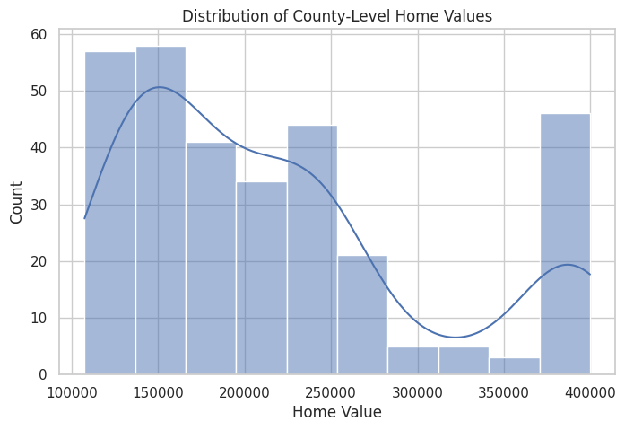

```python
plt.figure(figsize=(8,5))
sns.histplot(zhvi['Florida'], kde=True)  #
plt.title("Distribution of County‑Level Home Values")
plt.xlabel("Home Value")
plt.show()
```

Data Cleaning & Preprocessing

```python
zhvi_temp = zhvi.rename(columns={'Unnamed: 0': 'Date'})
zhvi_temp['Date'] = pd.to_datetime(zhvi_temp['Date'])

value_col = zhvi_temp['Date'].max()

zhvi_for_date = zhvi_temp[zhvi_temp['Date'] == value_col]

zhvi_clean = zhvi_for_date.melt(
    id_vars=['Date'],
    var_name='StateName',
    value_name='home_value'
)

zhvi_clean = zhvi_clean.drop(columns=['Date'])

zhvi_clean.head()
```

|  | StateName | home_value |
| --- | --- | --- |
| 0 | Florida | 372754.510594 |
| 1 | California | 765036.019732 |
| 2 | Texas | 297592.053510 |
| 3 | New York | 502162.146331 |
| 4 | Virginia | 405473.906761 |

```python
acs_cols = [
    'CensusTract',
    'State',
    'Income',
    'Poverty',
    'TotalPop',
    'Professional',
    'SelfEmployed',
    'Unemployment',
    'MeanCommute'
]

acs_clean = acs[acs_cols].copy()
acs_clean.head()
```

|  | CensusTract | State | Income | Poverty | TotalPop | Professional | SelfEmployed | Unemployment | MeanCommute |
| --- | --- | --- | --- | --- | --- | --- | --- | --- | --- |
| 0 | 1001020100 | Alabama | 61838.0 | 8.1 | 1948 | 34.7 | 4.6 | 5.4 | 25.0 |
| 1 | 1001020200 | Alabama | 32303.0 | 25.5 | 2156 | 22.3 | 6.1 | 13.3 | 23.4 |
| 2 | 1001020300 | Alabama | 44922.0 | 12.7 | 2968 | 31.4 | 12.3 | 6.2 | 19.6 |
| 3 | 1001020400 | Alabama | 54329.0 | 2.1 | 4423 | 27.0 | 3.1 | 10.8 | 25.3 |
| 4 | 1001020500 | Alabama | 51965.0 | 11.4 | 10763 | 49.6 | 5.3 | 4.2 | 24.8 |

Merge ZHVI + ACS

```python
acs_state_agg = acs_clean.groupby('State')[['Income', 'Poverty', 'TotalPop', 'Professional', 'SelfEmployed', 'Unemployment', 'MeanCommute']].mean().reset_index()
acs_state_agg = acs_state_agg.rename(columns={'State': 'StateName'})

df = zhvi_clean.merge(acs_state_agg, on='StateName', how='inner')
print("Merged shape:", df.shape)
df.head()
```

```
Merged shape: (50, 9)
```

|  | StateName | home_value | Income | Poverty | TotalPop | Professional | SelfEmployed | Unemployment | MeanCommute |
| --- | --- | --- | --- | --- | --- | --- | --- | --- | --- |
| 0 | Florida | 372754.510594 | 50690.194987 | 17.188406 | 4627.979270 | 33.546039 | 6.328853 | 10.021406 | 25.815159 |
| 1 | California | 765036.019732 | 67264.782303 | 16.550419 | 4768.705970 | 36.164614 | 8.592965 | 10.191290 | 27.877907 |
| 2 | Texas | 297592.053510 | 55874.522601 | 18.370897 | 5040.572460 | 32.622478 | 6.925120 | 7.391805 | 24.737860 |
| 3 | New York | 502162.146331 | 64290.749113 | 16.159219 | 4000.238715 | 37.219191 | 5.822101 | 8.717454 | 32.480614 |
| 4 | Virginia | 405473.906761 | 72866.013412 | 12.478922 | 4329.643419 | 41.022720 | 5.035627 | 6.911147 | 27.400107 |

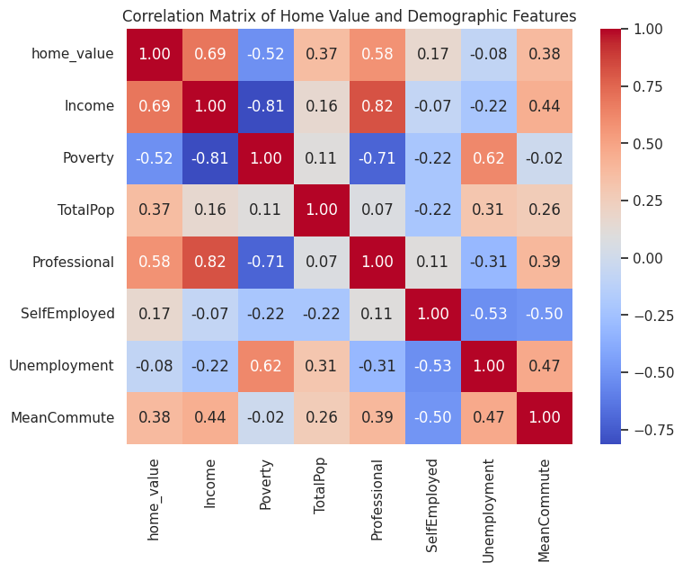

```python
correlation_matrix = df.corr(numeric_only=True)
plt.figure(figsize=(8, 6))
sns.heatmap(correlation_matrix, annot=True, cmap='coolwarm', fmt='.2f')
plt.title('Correlation Matrix of Home Value and Demographic Features')
plt.show()
```

Handle Missing Values

```python
df.isnull().sum().sort_values(ascending=False).head(10)
```

|  | 0 |
| --- | --- |
| StateName | 0 |
| home_value | 0 |
| Income | 0 |
| Poverty | 0 |
| TotalPop | 0 |
| Professional | 0 |
| SelfEmployed | 0 |
| Unemployment | 0 |
| MeanCommute | 0 |

**dtype:** int64

```python
df = df.dropna()
print("Rows after dropping missing:", df.shape[0])
```

```
Rows after dropping missing: 50
```

Feature Engineering & Train/Test Split

```python
df['log_home_value'] = np.log(df['home_value'])

feature_cols = [
    'Income',
    'Poverty',
    'TotalPop',
    'Professional',
    'SelfEmployed',
    'Unemployment',
    'MeanCommute'
]

X = df[feature_cols]
y = df['log_home_value']
```

```python
X_train, X_test, y_train, y_test = train_test_split(
    X, y, test_size=0.2, random_state=42
)

X_train.shape, X_test.shape
```

```
((40, 7), (10, 7))
```

**Modeling Approach**

**Models used:**

1. Linear Regression (baseline, interpretable)
2. Lasso Regression (regularization and feature selection)
3. Random Forest Regressor (nonlinear relationships and interactions)

**Evaluation Metrics:**

- RMSE (Root Mean Squared Error)
- MAE (Mean Absolute Error)
- R² (Coefficient of Determination)

**Model Implementation:**

Linear Regression

```python
lr = LinearRegression()
lr.fit(X_train, y_train)

pred_lr = lr.predict(X_test)

rmse_lr = np.sqrt(mean_squared_error(y_test, pred_lr))
mae_lr = mean_absolute_error(y_test, pred_lr)
r2_lr = r2_score(y_test, pred_lr)

rmse_lr, mae_lr, r2_lr
```

```
(np.float64(0.16924728572195374), 0.1516993001835127, 0.1835647949048217)
```

Lasso Regression

```python
lasso = Lasso(alpha=0.01, random_state=42)
lasso.fit(X_train, y_train)

pred_lasso = lasso.predict(X_test)

rmse_lasso = np.sqrt(mean_squared_error(y_test, pred_lasso))
mae_lasso = mean_absolute_error(y_test, pred_lasso)
r2_lasso = r2_score(y_test, pred_lasso)

rmse_lasso, mae_lasso, r2_lasso
```

```
(np.float64(0.18311248330296864), 0.16416728795158822, 0.044316246096610334)
```

Random Forest Regressor

```python
rf = RandomForestRegressor(n_estimators=100, random_state=42)
rf.fit(X_train, y_train)

pred_rf = rf.predict(X_test)

rmse_rf = np.sqrt(mean_squared_error(y_test, pred_rf))
mae_rf = mean_absolute_error(y_test, pred_rf)
r2_rf = r2_score(y_test, pred_rf)

rmse_rf, mae_rf, r2_rf
```

```
(np.float64(0.2077208868823089), 0.17027268372824764, -0.22981174077198796)
```

**Results and interpretation:**

After incorporating the additional demographic features, the models show varied performance. The Linear Regression model yielded an RMSE of 0.169, an MAE of 0.152, and an R-squared of 0.184. The Lasso Regression model, with its regularization, performed similarly, showing an RMSE of 0.183, an MAE of 0.164, and an R-squared of 0.044. Unfortunately, the Random Forest Regressor model performed the worst, with an RMSE of 0.208, an MAE of 0.170, and a negative R-squared of -0.230. This indicates that while Linear and Lasso Regression models now have positive R-squared values, suggesting a slight improvement over simply predicting the mean, their overall predictive power remains quite low. The Random Forest model's negative R-squared implies it's still performing worse than a basic mean-prediction baseline. Overall, the current set of features and models are not strongly predicting the log of home values at the state level.

**Model Evaluation Summary**

```python
results = pd.DataFrame({
    'Model': ['Linear Regression', 'Lasso', 'Random Forest'],
    'RMSE': [rmse_lr, rmse_lasso, rmse_rf],
    'MAE': [mae_lr, mae_lasso, mae_rf],
    'R2': [r2_lr, r2_lasso, r2_rf]
})

results
```

|  | Model | RMSE | MAE | R2 |
| --- | --- | --- | --- | --- |
| 0 | Linear Regression | 0.169247 | 0.151699 | 0.183565 |
| 1 | Lasso | 0.183112 | 0.164167 | 0.044316 |
| 2 | Random Forest | 0.207721 | 0.170273 | -0.229812 |

**Feature Importance (Random Forest)**

```python
importances = pd.Series(rf.feature_importances_, index=feature_cols)
importances.sort_values(ascending=False)
```

|  | 0 |
| --- | --- |
| Professional | 0.504918 |
| TotalPop | 0.175461 |
| Income | 0.109382 |
| Poverty | 0.076015 |
| SelfEmployed | 0.056665 |
| MeanCommute | 0.047858 |
| Unemployment | 0.029703 |

**dtype:** float64

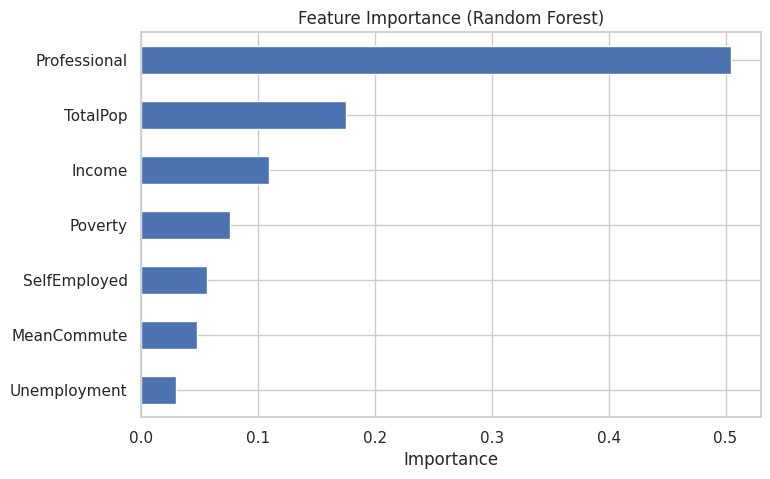

```python
plt.figure(figsize=(8,5))
importances.sort_values().plot(kind='barh')
plt.title("Feature Importance (Random Forest)")
plt.xlabel("Importance")
plt.show()
```

**Final Descriptive Charts**

Actual vs Predicted (Random Forest)

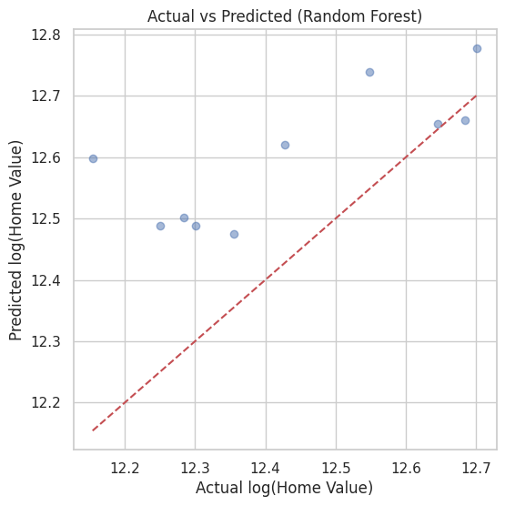

```python
plt.figure(figsize=(6,6))
plt.scatter(y_test, pred_rf, alpha=0.5)
plt.xlabel("Actual log(Home Value)")
plt.ylabel("Predicted log(Home Value)")
plt.title("Actual vs Predicted (Random Forest)")
plt.plot([y_test.min(), y_test.max()],
         [y_test.min(), y_test.max()],
         'r--')
plt.show()
```

**Relationship: Income vs Home Value**

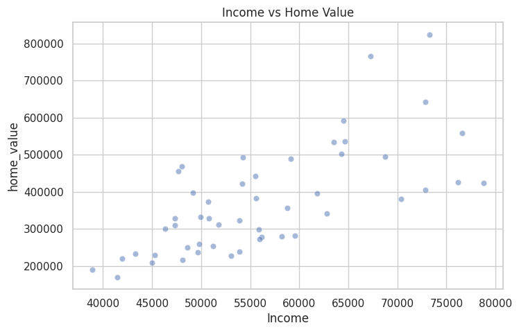

```python
plt.figure(figsize=(8,5))
sns.scatterplot(data=df, x='Income', y='home_value', alpha=0.5)
plt.title("Income vs Home Value")
plt.show()
```

# **Conclusions & Recommendations**

**Business Recommendations:**

- Zillow could incorporate more demographic and socioeconomic features into its pricing models to improve accuracy.
- Regional models could be tailored based on local income, education, and housing characteristics.
- Communicating the drivers of estimates can increase user trust in Zestimates.

**Next Steps:**

- Add interest‑rate and employment data (FRED, BLS).
- Explore time‑series forecasting of ZHVI.
- Build separate models for different regions or market segments.

```python
!jupyter nbconvert --to html "lab_14_api.ipynb"
```